# Sensitivity demo

```r
library("deSolve")
library("bbmle")
source("../R/fitSIR_funs.R")
```

I’m going to show how to use the sensitivity functions…

## Gradient function

I’m going to claim that this is the correct sensitivity equation:

$\begin{aligned} \frac{\partial}{\partial t}\frac{\partial I(t,\theta)}{\partial\theta} &= \frac{\partial f_I}{\partial\theta}\\ &= \frac{\partial f_I}{\partial S}\frac{\partial S}{\partial\theta} + \frac{\partial f_I}{\partial I}\frac{\partial I}{\partial\theta} + \frac{\partial f_I}{\partial\theta} \\ \end{aligned}$

## Example

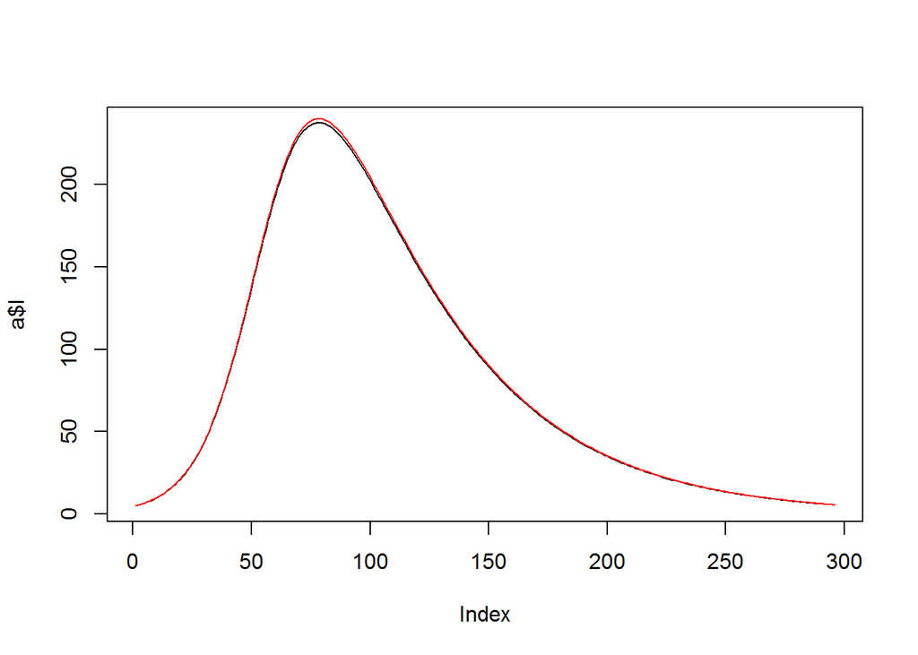

```r
tvec <- seq(1, 60, 0.2)

pars <- c(log.beta = -0.7,
    log.gamma = -2.3,
    log.N= 6.21,
    logit.i = -4.6)

pars2 <- c(log.beta = -0.7,
    log.gamma = -2.3,
    log.N= 6.22,
    logit.i = -4.6)

a = SIR.detsim(tvec, trans.pars(pars), findSens = TRUE)

a2 = SIR.detsim(tvec, trans.pars(pars2), findSens = TRUE)

z = (a2$I-a$I)/0.01

plot(a$I, type = "l")
lines(a2$I, col = "2")
```

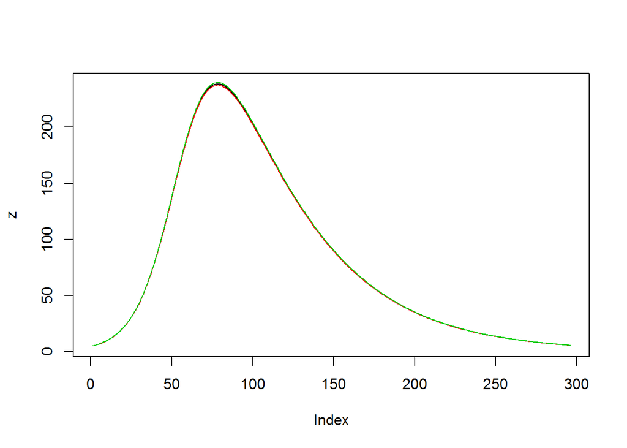

```r
plot(z, type = "l")

lines(a$nu_N_I, col = 2)

lines(a2$nu_N_I, col = 3)
```

## Bombay example - initial values

We start with these three equations:

$\begin{aligned} r &= \beta - \gamma,\\ -\frac{Q}{I_p} &= \frac{\beta\gamma}{N},\\ N - I_0 - \int I(t) dt = \frac{\gamma}{\beta}N, \end{aligned}$

$\begin{aligned} N &= - \gamma^2 \frac{I_p}{Q} + I_0 + \int I(t) dt\\ N &= - (\gamma+r) \gamma \frac{I_p}{Q} \end{aligned}$

This gives

$\begin{aligned} (\gamma+r) \gamma \frac{I_p}{Q} &= \gamma^2 \frac{I_p}{Q} - I_0 - \int I(t) dt\\ \gamma^2 \frac{I_p}{Q} + r \gamma \frac{I_p}{Q} &= \gamma^2 \frac{I_p}{Q} - I_0 - \int I(t) dt\\ r \gamma \frac{I_p}{Q} &=- (I_0 + \int I(t) dt)\\ \end{aligned}$

```r
library("fitsir")
```

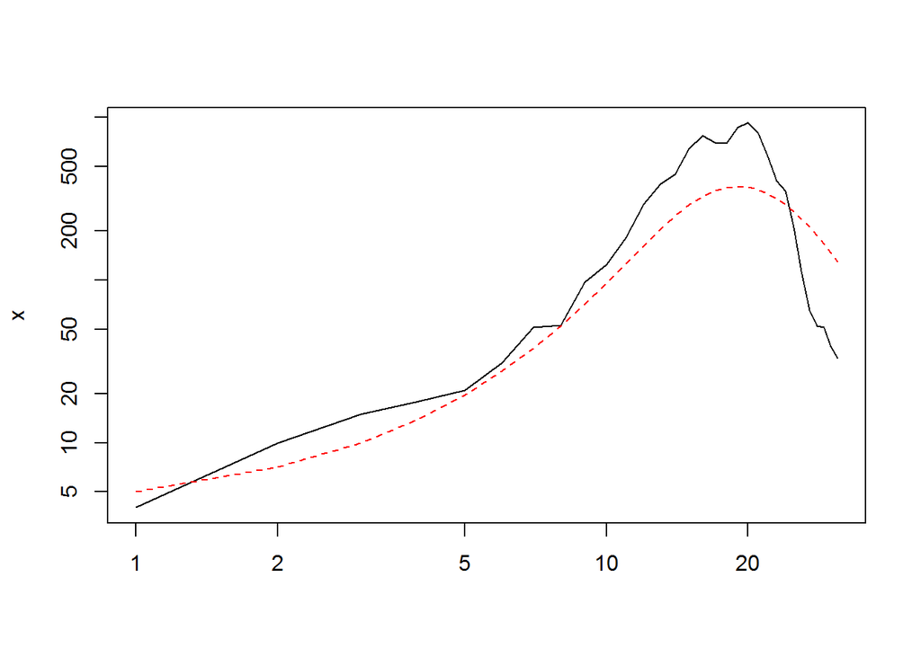

```
##        SSQ   SSQ_beta  SSQ_gamma      SSQ_N     SSQ_I0
##  1545688.9 -4997742.8  3161027.8 -2282666.0  -365863.1
```

```r
bombay2 <- setNames(bombay,c("tvec","count"))

iniP.ex <- startfun(data=bombay2, auto = TRUE)

findSens(bombay2, iniP.ex, plot.it = TRUE)
```

```r
(fitP <- coef(fitsir(bombay2, start = startfun(data = bombay2, auto = TRUE))))
```

```
##   log.beta  log.gamma      log.N    logit.i
##   3.307594   3.293212  15.934969 -14.625467
```

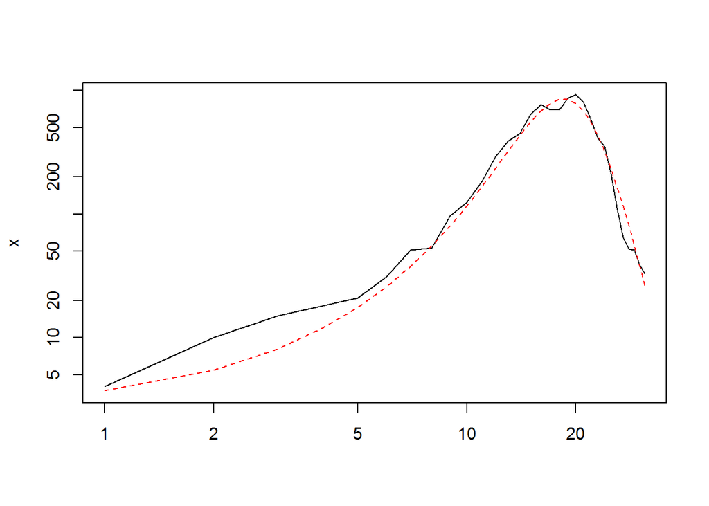

```
##           SSQ      SSQ_beta     SSQ_gamma         SSQ_N        SSQ_I0
##     97866.117 -23113319.185  23371770.069   -304031.176     -6550.103
```

```r
findSens(bombay2, fitP, plot.it = TRUE)
```

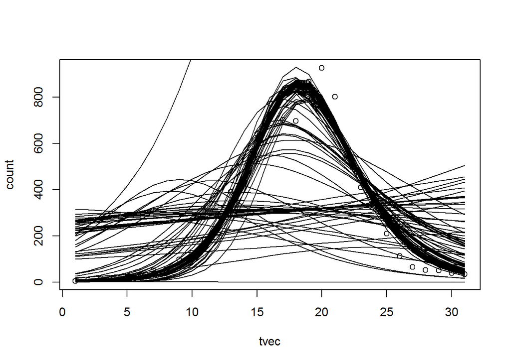

```
##   log.beta  log.gamma      log.N    logit.i
##   1.436391   1.339524  12.185920 -10.777176
```

```r
(fitP2 <- fitsir.optim(bombay2, start = startfun(), plot.it=TRUE))
```

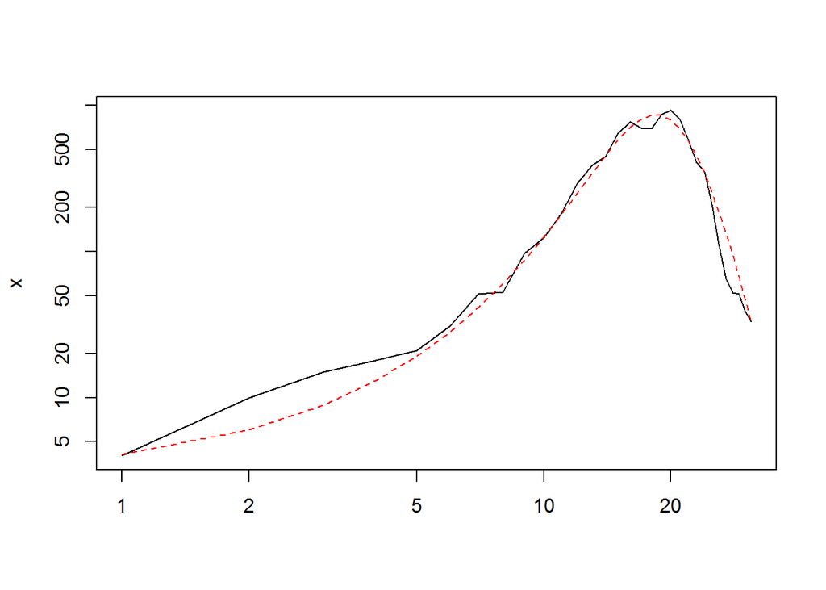

```
##         SSQ    SSQ_beta   SSQ_gamma       SSQ_N      SSQ_I0
##    95494.12 -1410218.24  1278343.95   -24553.05   -21992.63
```

```r
findSens(bombay2, fitP2, plot.it = TRUE)
```

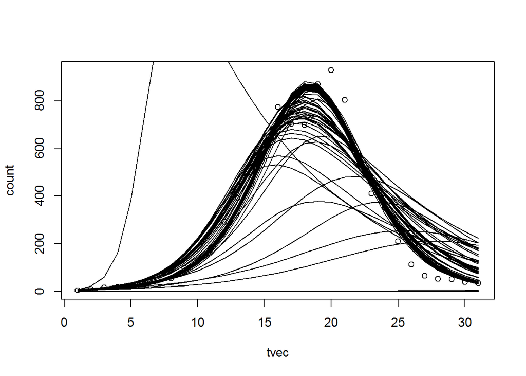

```
##   log.beta  log.gamma      log.N    logit.i
##   1.993483   1.940004  13.344892 -11.858999
```

```r
##with auto start?

(fitP3 <- fitsir.optim(bombay2, start = startfun(data=bombay2, auto = TRUE), plot.it=TRUE))
```

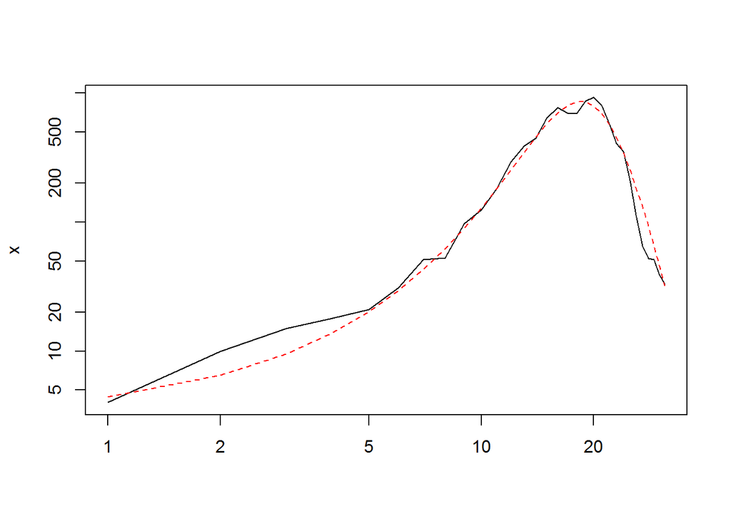

```
##         SSQ    SSQ_beta   SSQ_gamma       SSQ_N      SSQ_I0
##    92941.82 -1532154.29  1472585.96   -22737.70   -10562.92
```

```r
findSens(bombay2, fitP3, plot.it = TRUE)
```

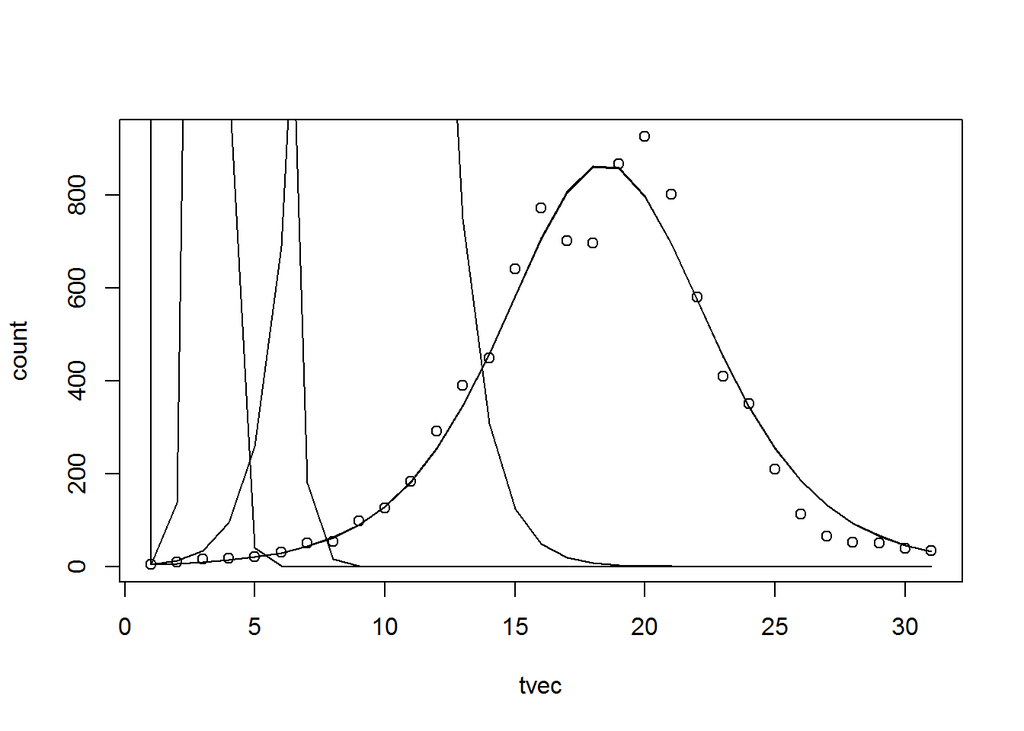

```
##   log.beta  log.gamma      log.N    logit.i
##   1.993364   1.939823  13.345088 -11.859005
```

```r
(fitP4 <- fitsir.optim(bombay2, start = fitP3, plot.it=TRUE))
```

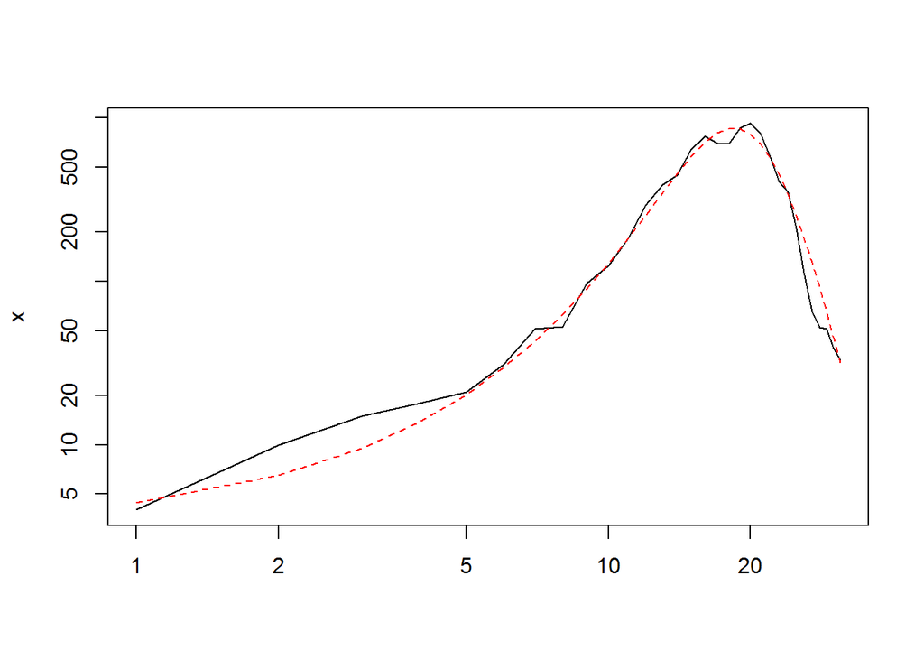

```
##        SSQ   SSQ_beta  SSQ_gamma      SSQ_N     SSQ_I0
## 92896.7904  -406.6436 -1506.2624 -1511.4749 -1032.6430
```

```r
findSens(bombay2, fitP4, plot.it = TRUE)
```

## Incidence

We need new equations for incidence… Let’s assume that bombay2 data is incidence data. We’re going to use $I(t)$ for incidence and $P(t)$ for prevalence from here.

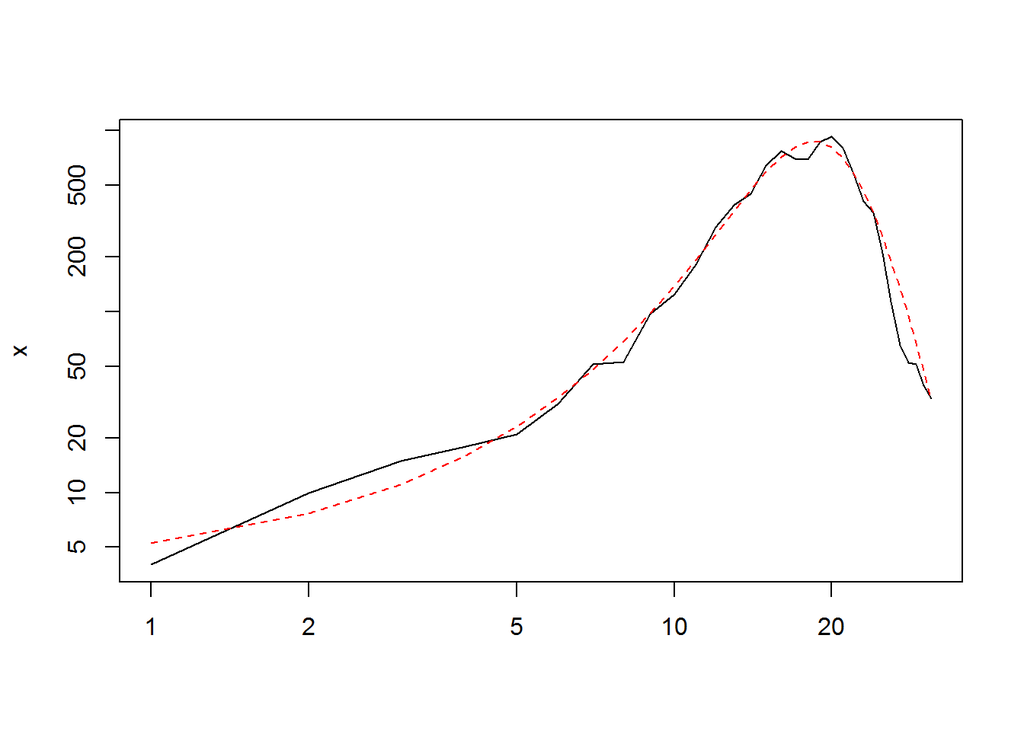

```
##          SSQ     SSQ_beta    SSQ_gamma        SSQ_N       SSQ_I0
## 9.149576e+04 1.448670e+04 6.941221e-04 1.554527e+05 1.120867e+03
```

```r
bombay2 <- setNames(bombay,c("tvec","count"))

fitP.inc <- coef(fitsir(bombay2, incidence = TRUE))

findSens(bombay2, fitP.inc, plot.it = TRUE, incidence = TRUE)
```

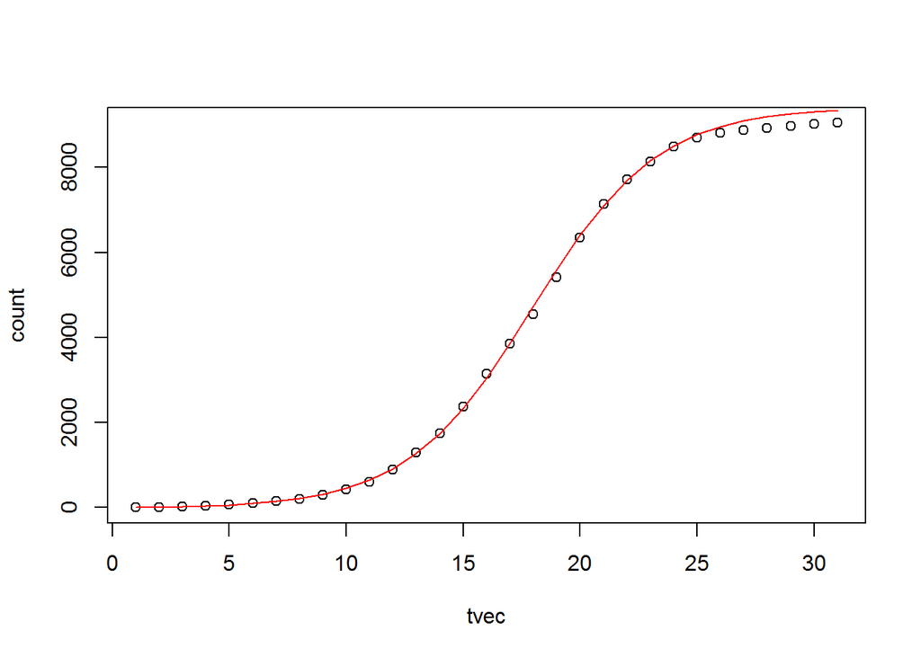

```r
bombay3 <- data.frame(tvec = bombay2$tvec, count = cumsum(bombay2$count))

plot(bombay3)

lines(cumsum(SIR.detsim(bombay2$tvec, trans.pars(fitP.inc), incidence = TRUE)), col = 2)
```

### Sensitivity

```r
tvec <- seq(1, 50, 0.5)

trans.pars(pars)
```

```
##         beta        gamma            N           i0
## 4.965853e-01 1.002588e-01 4.977013e+02 9.951802e-03
```

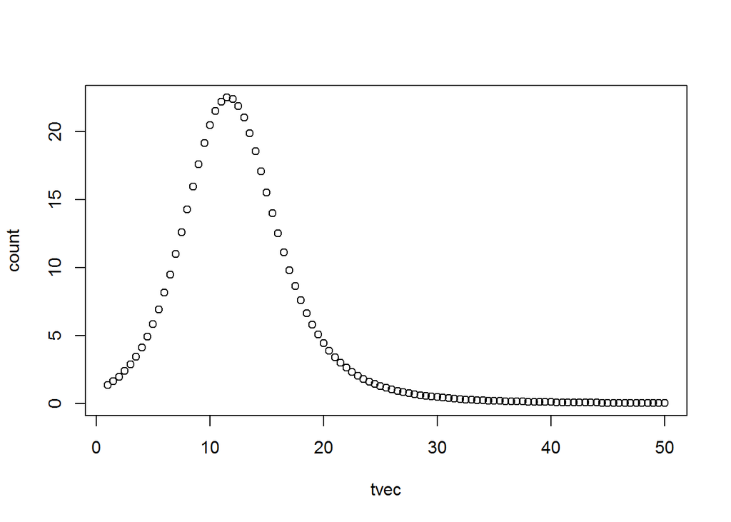

```r
fake.inc = data.frame(tvec, count = SIR.detsim(tvec, trans.pars(pars), incidence = TRUE))

plot(fake.inc)
```

```r
fake.P <- coef(fitsir(fake.inc, incidence = TRUE))

trans.pars(fake.P)
```

```
##         beta        gamma            N           i0
## 5.312641e-01 1.281330e-01 5.012693e+02 8.740637e-03
```

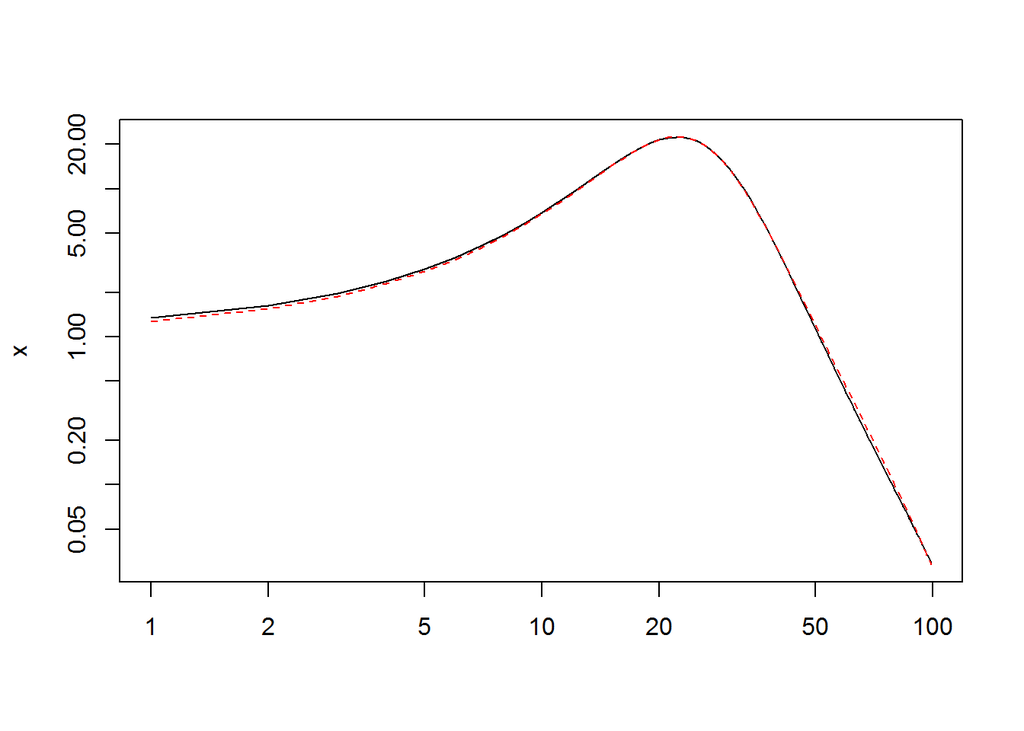

```
##         SSQ    SSQ_beta   SSQ_gamma       SSQ_N      SSQ_I0
##   0.3653922  -5.9298237   5.3216874 -36.2376741  -1.2427913
```

```r
findSens(fake.inc, fake.P, plot.it = TRUE, incidence = TRUE)
```

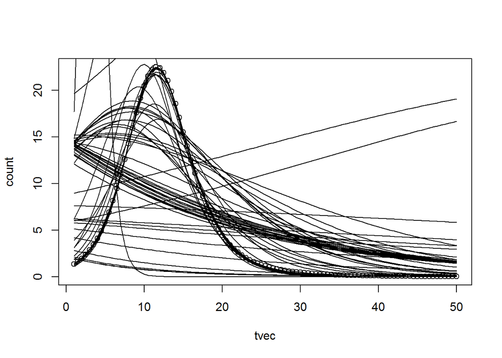

```
##    log.beta   log.gamma       log.N     logit.i
## -0.02601005 -0.57148501  6.53623300 -5.70428393
```

```r
(fake.P2 <- fitsir.optim(fake.inc, start = startfun(), plot.it=TRUE, incidence = TRUE))
```

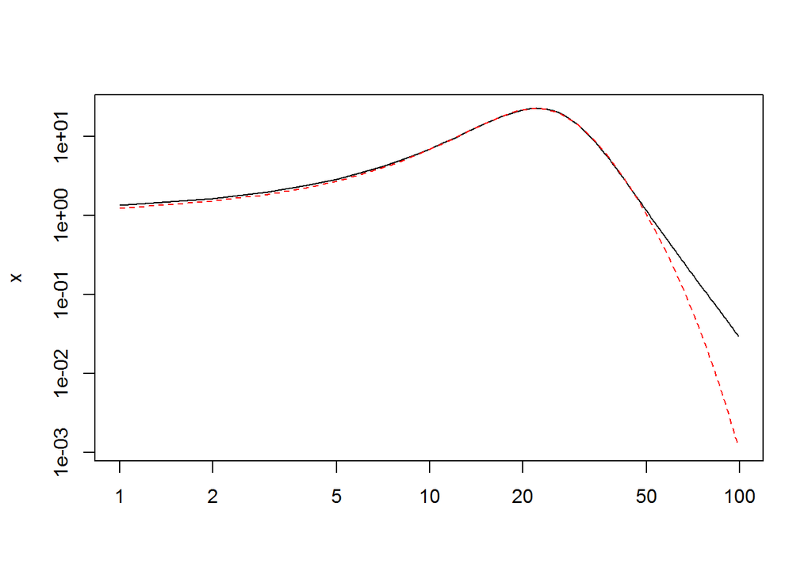

```
##           SSQ      SSQ_beta     SSQ_gamma         SSQ_N        SSQ_I0
##  1.3512449353 -0.0032288260  0.0013876027  0.0000747849 -0.0004996567
```

```r
findSens(fake.inc, fake.P2, plot.it = TRUE, incidence = TRUE)
```